# Data Exploration

François Delavy

12/27/2020

## Key Points

Quite some cleaning needed, in particular to group the categories. The protection object and authority are not usable because there are too many missing values. Need some checks to be sure that what we have correponds to the online database. If we want to do something with the decisions, we will have to extract it from the *html_text*.

How to treat the original/current cases?

### Cleanliness

- Too much missing data for the *protection object*,*specific questions*, and *authority*
- Need to work on grouping the categories of *authors*, *victims*, *means*, *social environment*, *ideology*. For readibility, because some overlap.

### Ideas, directions

- Extract the *decision* from *html_text*.
- Work with the original or current cases?

## Summary Figures

There are 1108 cases in the dataset, which spans from year 1995 to 2019. However, there are “only” 935 original cases, because second instance judgments do have a new case number, but not a new entry (URL)….  
The following figures were obtained by counting all the cases (i.e. *current_case*).

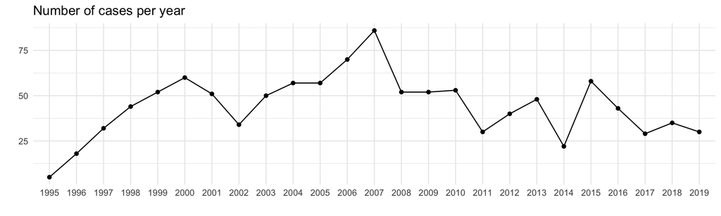

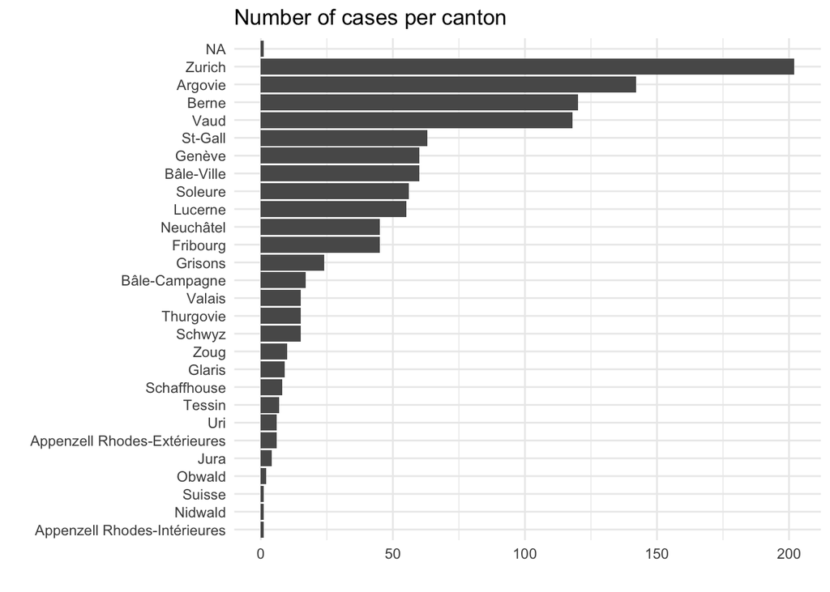

Note: there is one case where the location is “Suisse”, and one where it is missing.  
Idea: could import cantonal population data to show discrepancies.

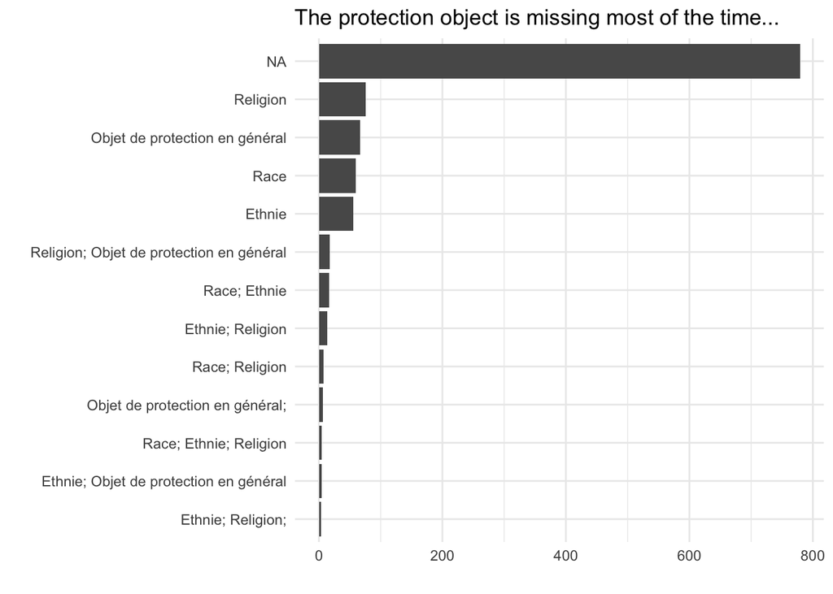

**TO DO**: Be sure that is also appear to be the case on the online ekr.admin.ch database, and that is corresponds to what is presented in the stats.

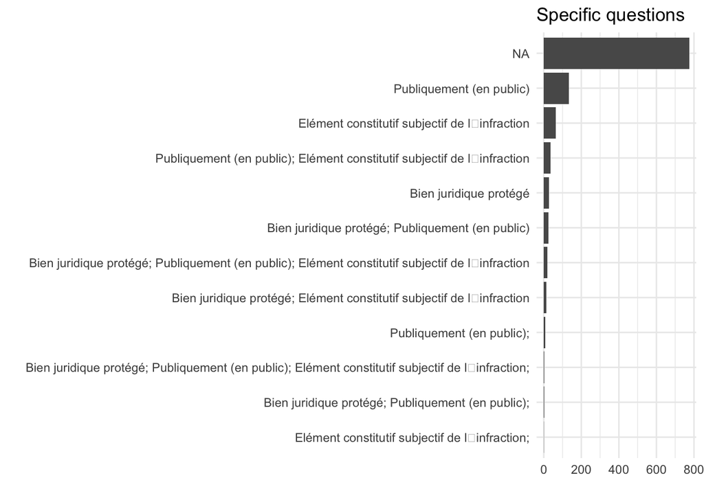

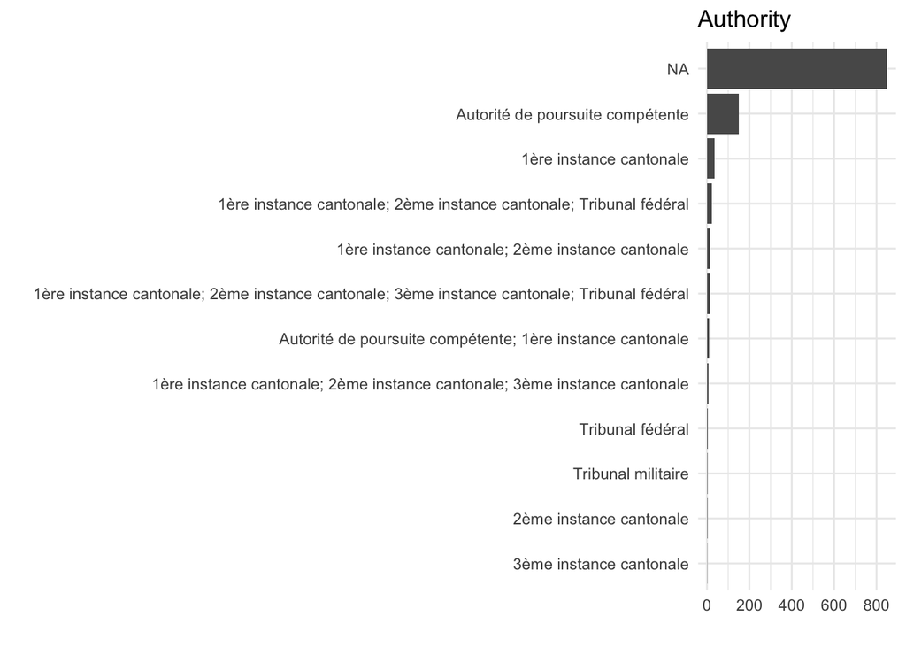

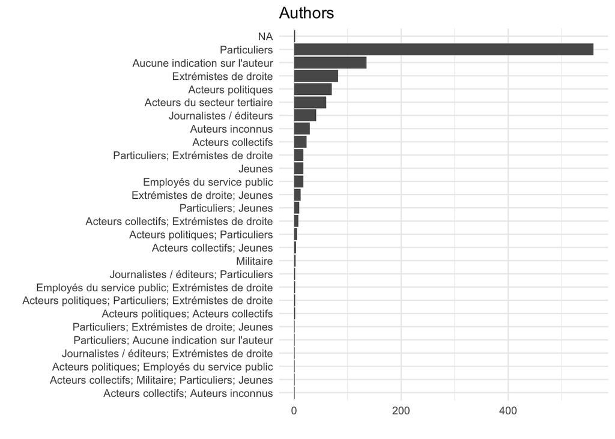

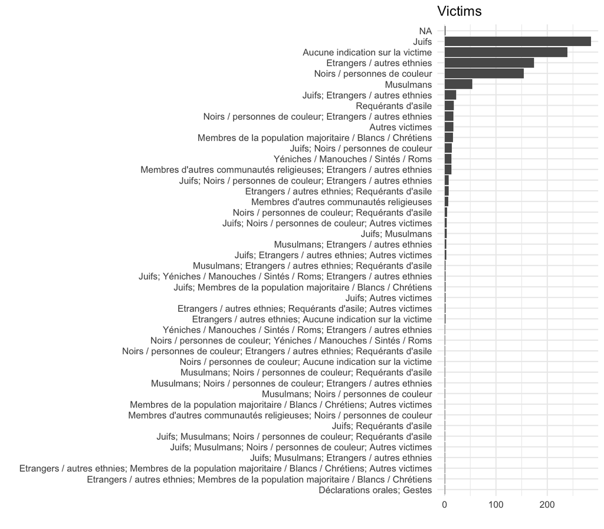

Note: There is 1 “Déclarations orales; Gestes”. It should be in the “means” column. **TO DO:** check that also error on database online and correct it.

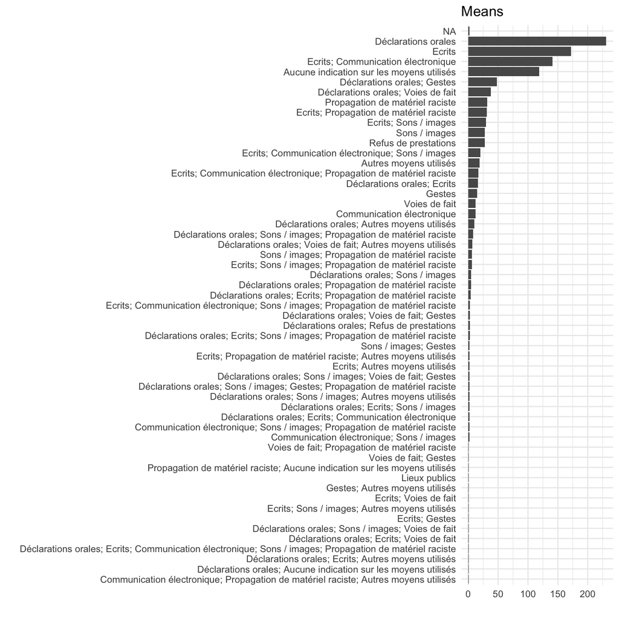

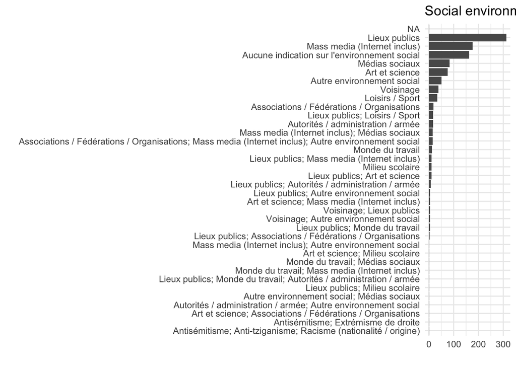

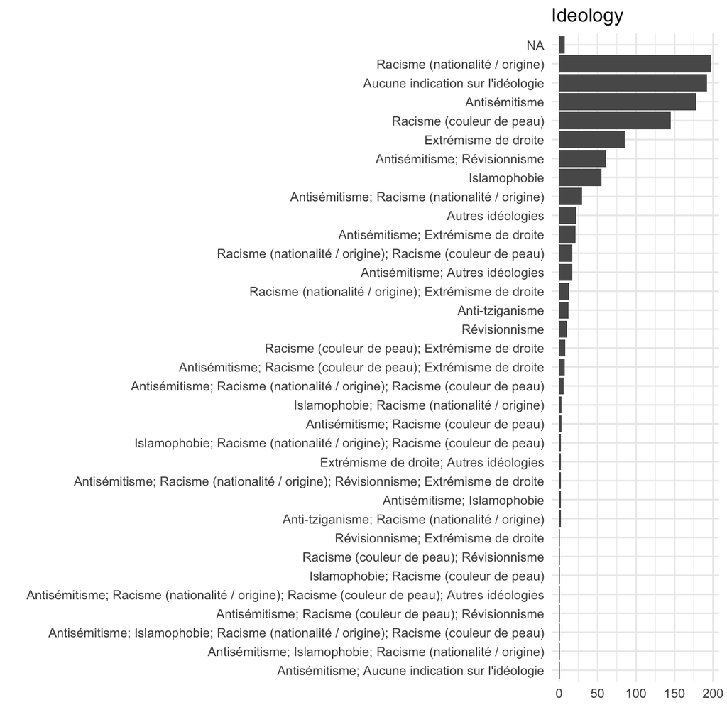